# Median Household Incomes in Canada

2024-11-23

## The Problem

- Have a product/service targeted to households with a certain household income
  - How to know which markets have enough areas with a high (or low) enough median household income to be viable target markets?
  - Once you have chosen a market, how do you target your marketing to specific areas?

## The Solution

- Statistics Canada performs a Census every 4 years
- Profiles of each *Forward Sortation Area (FSA)* (similar to a US Zip Code) include the median household income
- Need to identify Census Metropolitan Areas (cities and their surrounding communities) that have enough FSAs in the target range
- I’ve created a [web app](https://alexondrus.shinyapps.io/CanCensusMedIncome/) that displays this information and allows the user to download the results

## Example

Here’s the visual that is generated when the user selects Vancouver from the list of Canadian Census Metropolitan Areas:

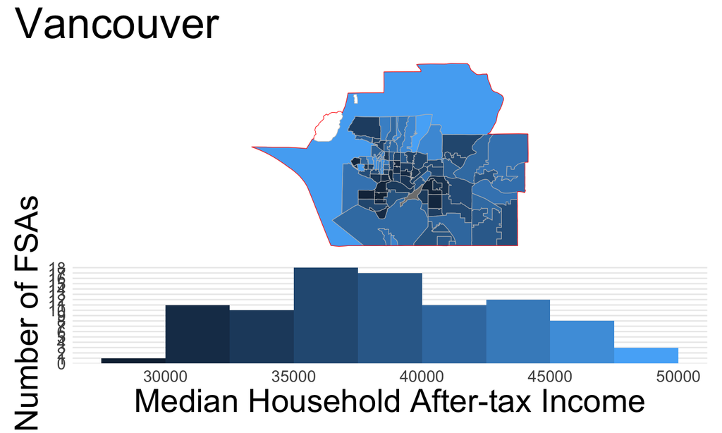

## Download

The ‘Download’ button allows the user to download the list of forward sortation areas along with the median household income for the chosen census metropolotian area.

Give it a try!